# RNA-seq Differential Expression Analysis of Exercise-Responsive Genes

Vinny Casilio

2026-04-21

## Introduction

In this assignment, you will analyze RNA-seq gene expression data from GEO dataset GSE120862. This dataset compares gene expression before and after an acute exercise condition. Your goal is to identify genes that change expression after exercise and interpret what those changes may mean biologically.

You will use a processed count matrix generated from the RNA-seq workflow:

FASTQ → FastQC → HISAT2 alignment → sorted BAM files → featureCounts → DESeq2

## Learning Objectives

By the end of this assignment, you should be able to:

- Load a gene count matrix into R
- Create sample metadata for a paired RNA-seq experiment
- Run DESeq2 differential expression analysis
- Interpret log2 fold change and adjusted p-values
- Generate a volcano plot and PCA plot
- Identify strongly upregulated and downregulated genes
- Identify genes using public databases

## Load Required Packages

If you do not have DESeq2 installed, run this block. Otherwise proceed to next code chunk

```r
# Install DESeq2 if not already installed

if (!requireNamespace("BiocManager", quietly = TRUE)) {
  install.packages("BiocManager")
}

if (!requireNamespace("DESeq2", quietly = TRUE)) {
  BiocManager::install("DESeq2")
}

library(DESeq2)
```

Run this block to import your libraries:

```r
library(DESeq2)
library(ggplot2)
```

Load the Count Matrix

The file gene_counts_clean.txt was produced using featureCounts. Each row represents a gene, and each sample column contains the number of aligned reads assigned to that gene.

```r
counts_raw <- read.delim("gene_counts_clean.txt",
                         comment.char = "#",
                         check.names = FALSE)

head(counts_raw)
```

```
##              Geneid                                                    Chr
## 1 ENSG00000290825.1                                         chr1;chr1;chr1
## 2 ENSG00000223972.6                          chr1;chr1;chr1;chr1;chr1;chr1
## 3 ENSG00000227232.5 chr1;chr1;chr1;chr1;chr1;chr1;chr1;chr1;chr1;chr1;chr1
## 4 ENSG00000278267.1                                                   chr1
## 5 ENSG00000243485.5                               chr1;chr1;chr1;chr1;chr1
## 6 ENSG00000284332.1                                                   chr1
##                                                               Start
## 1                                                 11869;12613;13221
## 2                               12010;12179;12613;12975;13221;13453
## 3 14404;15005;15796;16607;16858;17233;17606;17915;18268;24738;29534
## 4                                                             17369
## 5                                     29554;30267;30564;30976;30976
## 6                                                             30366
##                                                                 End
```

[output cut: 20 more lines]

## Create the Count Matrix

featureCounts includes several annotation columns before the actual sample count columns. For DESeq2, we only need the gene IDs and the six sample columns.

```r
count_matrix <- counts_raw[, c("Geneid",
                               "SRR7967702",
                               "SRR7967703",
                               "SRR7967714",
                               "SRR7967715",
                               "SRR7967726",
                               "SRR7967727")]

rownames(count_matrix) <- count_matrix$Geneid
count_matrix$Geneid <- NULL

count_matrix <- round(as.matrix(count_matrix))

head(count_matrix)
```

```
##                   SRR7967702 SRR7967703 SRR7967714 SRR7967715 SRR7967726
## ENSG00000290825.1          0          0          0          0          0
## ENSG00000223972.6          0          0          0          0          0
## ENSG00000227232.5          2         43          0          2         20
## ENSG00000278267.1          0          0          0          0          0
## ENSG00000243485.5          0          0          0          0          0
## ENSG00000284332.1          0          0          0          0          0
##                   SRR7967727
## ENSG00000290825.1          0
## ENSG00000223972.6          0
## ENSG00000227232.5          1
## ENSG00000278267.1          2
## ENSG00000243485.5          0
## ENSG00000284332.1          0
```

## Create Sample Metadata

The metadata describes the experimental design. In this dataset, each subject has a baseline sample and a post-exercise sample. This allows us to use a paired design.

```r
metadata <- data.frame(
  sample = c("SRR7967702", "SRR7967703",
             "SRR7967714", "SRR7967715",
             "SRR7967726", "SRR7967727"),

  subject = factor(c("1", "1",
                     "2", "2",
                     "3", "3")),

  time_point = factor(c("baseline", "post",
                        "baseline", "post",
                        "baseline", "post"),
                      levels = c("baseline", "post"))
)

rownames(metadata) <- metadata$sample

metadata
```

```
##                sample subject time_point
## SRR7967702 SRR7967702       1   baseline
## SRR7967703 SRR7967703       1       post
## SRR7967714 SRR7967714       2   baseline
## SRR7967715 SRR7967715       2       post
## SRR7967726 SRR7967726       3   baseline
## SRR7967727 SRR7967727       3       post
```

Check That Sample Names Match

Before running DESeq2, the columns of the count matrix must match the rows of the metadata.

```r
count_matrix <- count_matrix[, rownames(metadata)]

all(colnames(count_matrix) == rownames(metadata))
```

```
## [1] TRUE
```

## Run DESeq2

The design formula below controls for differences between subjects while testing for expression differences between baseline and post-exercise samples.

```r
dds <- DESeqDataSetFromMatrix(
  countData = count_matrix,
  colData = metadata,
  design = ~ subject + time_point
)
dds <- dds[rowSums(counts(dds)) >= 10, ]

dds <- DESeq(dds)
res <- results(dds,
               contrast = c("time_point", "post", "baseline"))

res <- res[order(res$padj), ]

summary(res)
```

```
##
## out of 22770 with nonzero total read count
## adjusted p-value < 0.1
## LFC > 0 (up)       : 399, 1.8%
## LFC < 0 (down)     : 187, 0.82%
## outliers [1]       : 0, 0%
## low counts [2]     : 6181, 27%
## (mean count < 10)
## [1] see 'cooksCutoff' argument of ?results
## [2] see 'independentFiltering' argument of ?results
```

```r
head(res)
```

```
## log2 fold change (MLE): time_point post vs baseline
## Wald test p-value: time point post vs baseline
## DataFrame with 6 rows and 6 columns
##                     baseMean log2FoldChange     lfcSE      stat       pvalue
##                    <numeric>      <numeric> <numeric> <numeric>    <numeric>
## ENSG00000119508.18 10523.533        6.57835  0.238540   27.5776 2.06775e-167
## ENSG00000185022.12  2995.795        6.18193  0.257706   23.9883 3.68412e-127
## ENSG00000123358.20 12112.438        3.54327  0.242375   14.6190  2.12621e-48
## ENSG00000144136.11  1279.378        2.37799  0.187286   12.6971  6.13624e-37
## ENSG00000006210.7    935.428        2.37540  0.188171   12.6236  1.56459e-36
## ENSG00000112715.26 11868.270        2.07172  0.164418   12.6004  2.10207e-36
##                            padj
##                       <numeric>
## ENSG00000119508.18 3.43019e-163
## ENSG00000185022.12 3.05580e-123
## ENSG00000123358.20  1.17572e-44
## ENSG00000144136.11  2.54485e-33
## ENSG00000006210.7   5.19100e-33
## ENSG00000112715.26  5.81188e-33
```

Save Results

```r
write.csv(as.data.frame(res),
          "deseq2_post_vs_baseline.csv")

sig <- subset(as.data.frame(res),
              padj < 0.05)

write.csv(sig,
          "significant_genes_padj_0.05.csv")
```

Explore your results, use head to explore the results.

```r
head(sig)
```

```
##                      baseMean log2FoldChange     lfcSE     stat        pvalue
## ENSG00000119508.18 10523.5331       6.578347 0.2385398 27.57757 2.067747e-167
## ENSG00000185022.12  2995.7952       6.181931 0.2577061 23.98830 3.684125e-127
## ENSG00000123358.20 12112.4377       3.543275 0.2423753 14.61896  2.126209e-48
## ENSG00000144136.11  1279.3784       2.377988 0.1872859 12.69710  6.136238e-37
## ENSG00000006210.7    935.4275       2.375398 0.1881709 12.62362  1.564590e-36
## ENSG00000112715.26 11868.2696       2.071723 0.1644179 12.60035  2.102073e-36
##                             padj
## ENSG00000119508.18 3.430186e-163
## ENSG00000185022.12 3.055797e-123
## ENSG00000123358.20  1.175723e-44
## ENSG00000144136.11  2.544851e-33
## ENSG00000006210.7   5.190996e-33
## ENSG00000112715.26  5.811881e-33
```

## Question 1: Interpreting DESeq2 Output

Briefly explain what each of the following columns means:

baseMean log2FoldChange pvalue padj

The baseMean column represents the average normalized read count for each gene across all samples in the dataset. It reflects how strongly a gene is expressed overall, independent of whether its expression changes between conditions. Genes with higher baseMean values are generally expressed at higher levels.

The log2FoldChange column shows how much a gene’s expression changes between the two experimental conditions (post-exercise vs baseline). A positive value means the gene is expressed at higher levels after exercise, while a negative value means expression is lower after exercise. Because the value is on a log₂ scale, a value of 1 means expression doubled, and a value of −1 means expression was reduced by half.

The pvalue indicates the probability that the observed difference in gene expression occurred by chance. Smaller p-values suggest stronger evidence that the gene is differentially expressed between conditions. However, because RNA-seq experiments test thousands of genes at once, p-values alone are not sufficient to determine significance.

The padj column shows the adjusted p-value after correcting for multiple hypothesis testing using a false discovery rate (FDR) method. This correction reduces the likelihood of false positives when many genes are tested simultaneously. Genes with padj values less than 0.05 are typically considered significantly differentially expressed.

## Volcano plot

A volcano plot shows both the size of expression change and the statistical significance of each gene.

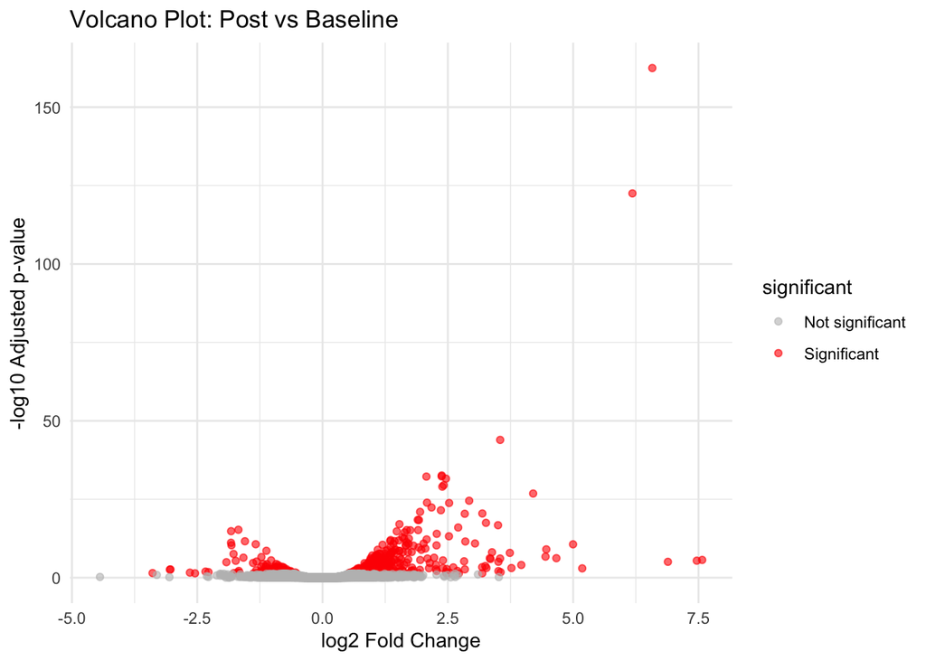

```r
res_df <- as.data.frame(res)
res_df <- res_df[!is.na(res_df$padj), ]

res_df$significant <- "Not significant"
res_df$significant[res_df$padj < 0.05] <- "Significant"

volcano_plot <- ggplot(res_df,
                       aes(x = log2FoldChange,
                           y = -log10(padj),
                           color = significant)) +
  geom_point(alpha = 0.6) +
  scale_color_manual(values = c("Not significant" = "grey",
                                "Significant" = "red")) +
  theme_minimal() +
  labs(title = "Volcano Plot: Post vs Baseline",
       x = "log2 Fold Change",
       y = "-log10 Adjusted p-value")

volcano_plot
```

Save your plot

```r
ggsave("volcano_plot.png",
       plot = volcano_plot,
       width = 7,
       height = 6)
```

## Question 2: Volcano Plot Interpretation

What does the volcano plot show about gene expression after exercise?

The volcano plot shows that a subset of genes changes expression significantly after exercise, while most genes remain close to their baseline expression levels. Many of the significantly differentially expressed genes appear on the positive side of the log₂ fold change axis, indicating increased expression after exercise, although some genes also show decreased expression. The genes highlighted with higher −log₁₀ adjusted p-values represent the most statistically significant expression changes. Overall, the volcano plot demonstrates that exercise produces measurable transcriptional changes across multiple genes, supporting the conclusion that exercise has a coordinated effect on gene expression.

## Question 3: Most upregulated genes

First we are going to add a significance filter to ensure we only select significant results. Run this block of code

```r
sig <- res_df[res_df$padj < 0.05, ]

head(sig[order(-sig$log2FoldChange), ], 2)
```

```
##                   baseMean log2FoldChange   lfcSE     stat       pvalue
## ENSG00000287403.1 20.29071       7.573763 1.33849 5.658439 1.527557e-08
## ENSG00000279685.2 19.78239       7.465833 1.34398 5.555020 2.775807e-08
##                           padj significant
## ENSG00000287403.1 2.165867e-06 Significant
## ENSG00000279685.2 3.774415e-06 Significant
```

```r
head(sig[order(sig$log2FoldChange), ], 2)
```

```
##                    baseMean log2FoldChange     lfcSE      stat       pvalue
## ENSG00000276409.5  11.94334      -3.391545 1.0111128 -3.354269 7.957486e-04
## ENSG00000124253.11 23.91457      -3.046792 0.7420735 -4.105782 4.029499e-05
##                           padj significant
## ENSG00000276409.5  0.033162848 Significant
## ENSG00000124253.11 0.002666341 Significant
```

ENSG00000287403.1 log2fold change of 7.573763 ENSG00000279685.2 log2fold change of 7.465833

Use NCBI Gene, Ensembl, UniProt, or Gene Ontology to look up each gene’s name or description if no unique name given.

ENSG00000287403.1 - Novel transcript, antisense to RPTOR ENSG00000279685.2 - MAPT-IT1

###Question 4: Most Downregulated Genes Identify the two genes with the greatest expression decrease after exercise.

ENSG00000276409.5 log2fold change of -3.391545 ENSG00000124253.11 log2fold change of -3.046792

Use NCBI Gene, Ensembl, UniProt, or Gene Ontology to look up each gene’s function.

ENSG00000276409.5 - CCL14 ENSG00000124253.11 - PCK1

## Question 5: Biological Interpretation

The gene PPARGC1A encodes PGC-1α, a transcriptional coactivator that plays an important role in regulating mitochondrial biogenesis and energy metabolism. This gene is widely known to respond to endurance exercise and contributes to cellular adaptations that improve metabolic efficiency and support long-term physiological changes in skeletal muscle and other tissues.

Question:

Based on its biological function, would you expect PPARGC1A expression to increase or decrease after exercise? Explain your reasoning.

I would expect regulation to increase, it is widely know to respond to endurance exercise and contributes to metabolic adaptations.

Now lets verify, the ENS number for PPARGC1A is ENSG00000109819

```r
res$gene_id <- sub("\\..*", "", rownames(res))

ppargc1a <- res[res$gene_id == "ENSG00000109819", ]

ppargc1a
```

```
## log2 fold change (MLE): time_point post vs baseline
## Wald test p-value: time point post vs baseline
## DataFrame with 1 row and 7 columns
##                    baseMean log2FoldChange     lfcSE      stat    pvalue
##                   <numeric>      <numeric> <numeric> <numeric> <numeric>
## ENSG00000109819.9   2676.95       0.143245  0.199031  0.719709  0.471704
##                        padj         gene_id
##                   <numeric>     <character>
## ENSG00000109819.9  0.935863 ENSG00000109819
```

What do the results show?

PPARGC1A is not statistically significantly upregulated, even though it has a log2fold change of +0.143, its p-adjusted value is greater than 0.05

## PCA Plot

Principal component analysis helps show whether samples cluster by condition.

```r
vsd <- vst(dds, blind = FALSE)

pca_plot <- plotPCA(vsd, intgroup = "time_point")
```

```
## using ntop=500 top features by variance
```

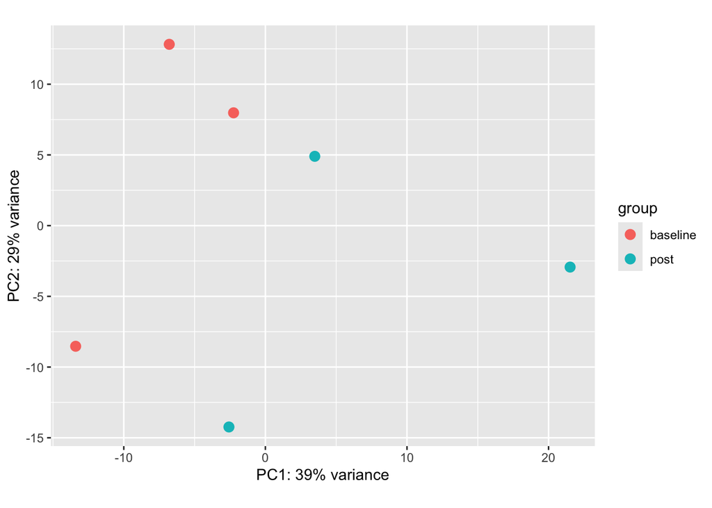

```r
pca_plot
```

Save plot

```r
ggsave("PCA_plot.png",
       plot = pca_plot,
       width = 7,
       height = 6)
```

## Question 6: PCA Interpretation

Do baseline and post-exercise samples separate from each other in the PCA plot? What does this suggest about the effect of exercise on gene expression?

### Save and knit this file as an html. Turn in your knitted file with all the questions answered and attached your two charts